# Comparisons LPD - SDi experimental

# Introduction

In this report we compare different LPD measures (their inverse, 1/CN and 1/WCN), with SDi experimental profiles. We do this because theoretical SDi is proportional to 1/CN or 1/WCN (depending on the ENM used to generate mutants). Then, using different R0 to calculate CN, we can get an idea of the results that will come from the simulations and choose some values of R0 to generate mutants. Theoretical SDi of ANM is proportional to 1/CN with an r of aprox. 0.97, meanwhile theoretical SDi of pfANM is proportional to 1/WCN with a lower value of r. To calculate LPD measures, we used only CA of aa (“CA”), and both CA and CM (“CM”). We compare the results obtained for different families. To do this, we use correlations calculated by the program “analysis-structure-CN-WCN-exp.Rmd”. The first 6 figures correspond to the mean correlation between 1/LPD (CN or WCN) and experimental SDi, where the mean is calculated over the families. The last 6 figures show in different colors the values obtanied for each family.

p = pearson correlation coef, s = spearman correlation coef.

```
## [1] "families"
```

```
## [1] "sh3"
## [1] "snakesToxin"
## [1] "globins"
## [1] "az"
## [1] "phoslip"
## [1] "fabp"
## [1] "rrm"
## [1] "serinProteases"
```

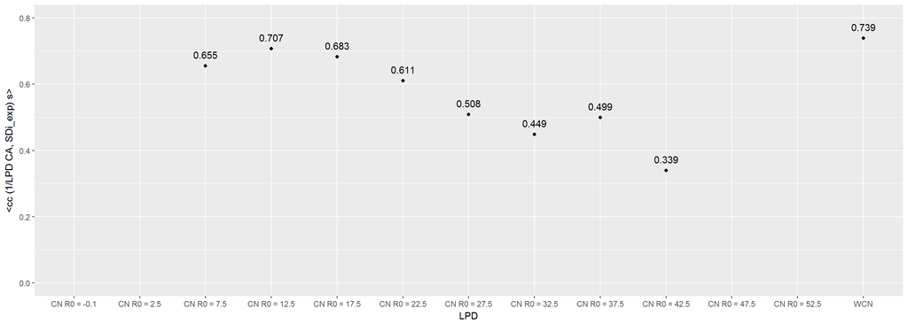

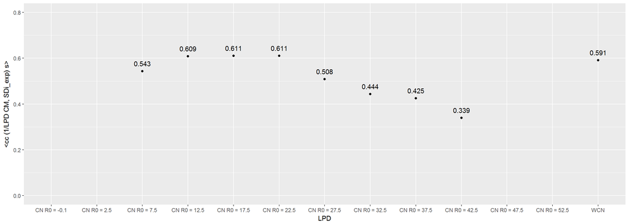

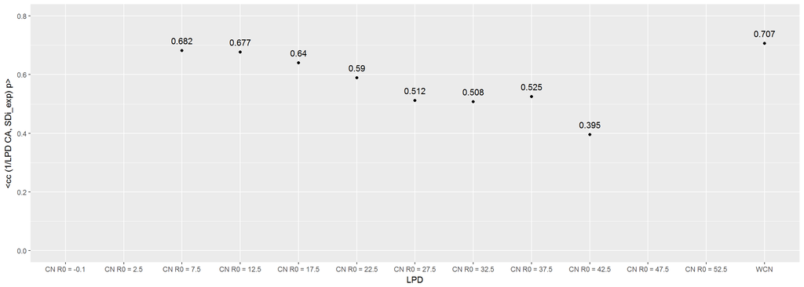

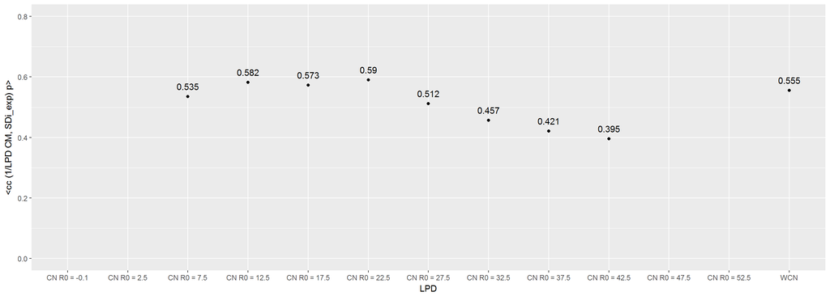

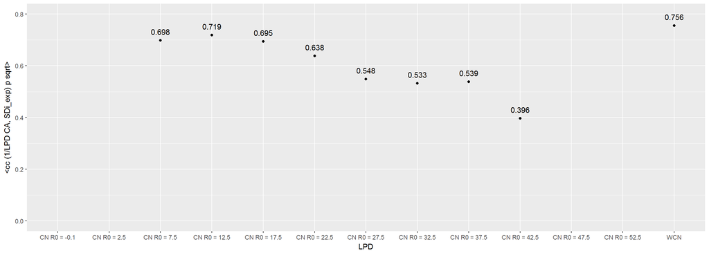

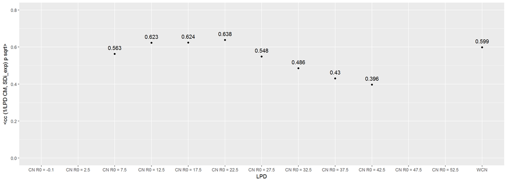

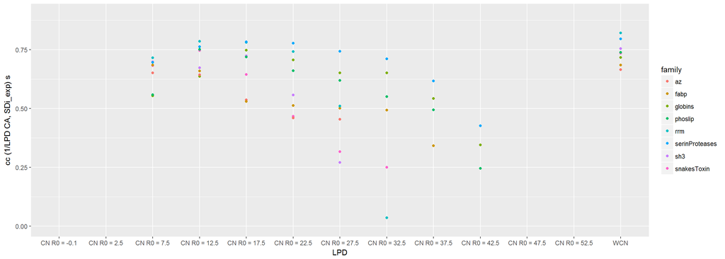

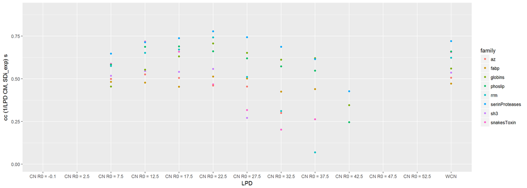

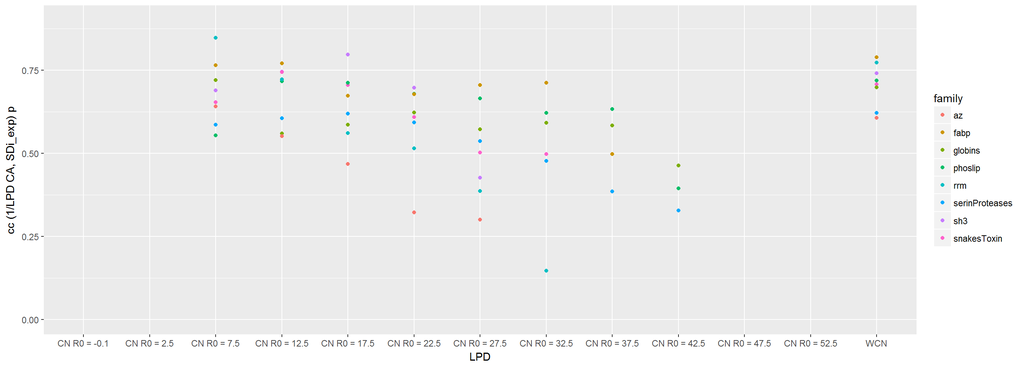

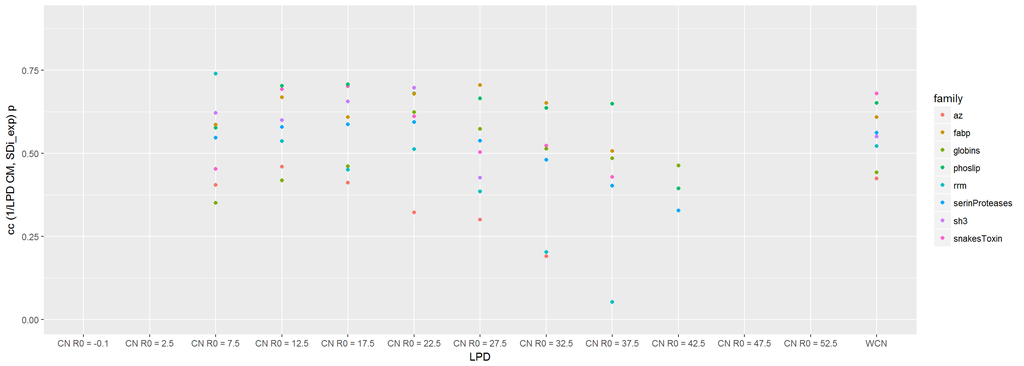

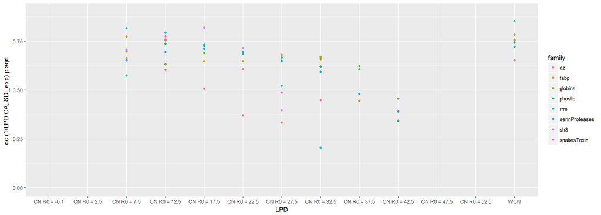

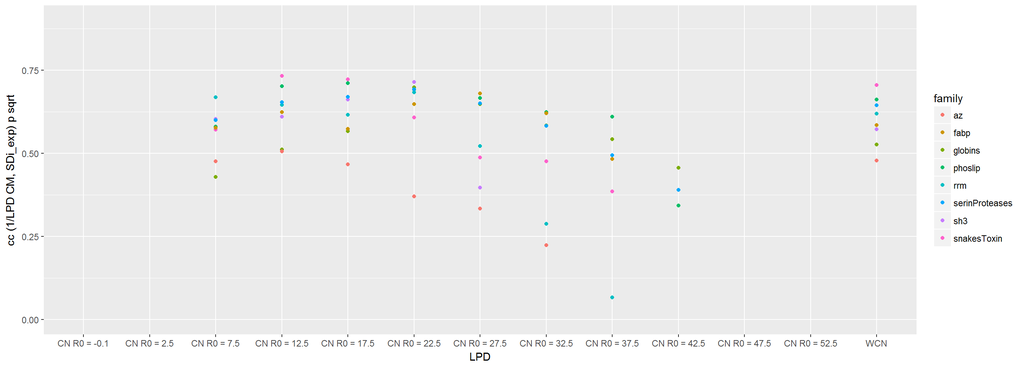